# Human Activity Recognition

### Summary

The goal of this paper is to develop a prediction model which is based on the Human Activity Recognition data set. The dataset provides information regarding how well barbell lifts were performed by 6 healthy subjects. The participants were asked to perform one set of 10 repetitions of the Unilateral Dumbbell Biceps Curl in five different fashions: exactly according to the specification (Class A), throwing the elbows to the front (Class B), lifting the dumbbell only halfway (Class C), lowering the dumbbell only halfway (Class D) and throwing the hips to the front (Class E). The data is collected by having accelerometers mounted on the belt, forearm, arm, and dumbell. The purspose of the study is to investigate how well the activity was performed by the wearer. More information regarding the collection of the data could be found at http://groupware.les.inf.puc-rio.br/work.jsf?p1=10335 under the section Weight Lifting Exerceis Dataset.

### Analysys

**1. Pre-processing of the data**

The first step is to load the data into a training, testing and validation sets. The model will be developed be developed by using the training and the testing set. The validation set will be used for one time testing after which will determine the out of sample error. First we are going to split the data into to part(80% and 20%). The smaller part will be our Validation set. The bigger part will be consequently split into two sections (70% and 30%). The bigger portion is the Train set ad the smaller portion is the Test set. The prediciton model which shows the best results on the Validation set data will be selected as the best model.

The dimensions of the initial dataset are:

```r
dim(pmlTraining)
```

```
## [1] 19622   160
```

After splitting the datasets we have Training, Testing and Validation with fewer number of observations but with equal amount of variables. Some variables are categorical, there is a possibility of correlations existing among the variables and for that reason we are going to perform preprocessing of the data.

For the purspose of analysing the dataset, we are going to convert them to dummy variables.

```r
dummies = dummyVars(classe~., data=formulaTraining)
```

The next step is to remove the Near Zero-Variance Predictors which are predictors with only one single unique value.

```r
nzv <- nearZeroVar(formulaTrainingDummies)
```

In our training dataset, we had 6,988 variables after creating the dummy variables. After removing the near-zero variance predictors, the number of variables decreased to 114 which would help us simplify the model and make it faster.

[output not shown]

```r
descrCor = cor(formulaTrainingDummiesNZV, use="complete.obs")
highlyCorDescr = findCorrelation(descrCor, cutoff = .75)
```

**2. Linear regression with k-fold cross validation**

The data in our training and testing dataset is being pre processed and the next step is to run few models on the data and check which one predicts best the testing dataset. The first model is going to be a linear regression model with cross validation. Based on the number of rows in the dataset and the fact that we would like to have a reasonable amount of processor time to build the model, we are going to set the number of folds to 5.

```r
cvCtrl <- trainControl(method = "cv", number=5, allowParallel = TRUE)
trainObjLM = train(classe~., data=Training, method="lm", trControl=cvCtrl, verbose=FALSE)
```

```r
confMatrixLM = confusionMatrix(predTestingGLM, Testing$classe)
confMatrixLM$overall['Accuracy']
```

```
## Accuracy
##        1
```

```r
confMatrixLM$overall['Kappa']
```

```
## Kappa
##     1
```

The linear regression model gives very high results for the accuracy and the kappa value however this could be due to over fitting. We will explore another model based on Linear regression but with the addition of stepwise selection; this model has a tuning parameter nvmax(Maximum Number of Predictors)

[output not shown]

[output not shown]

```r
cvCtrl <- trainControl(method = "cv", number=3, allowParallel = TRUE)
trainObjleapForward = train(classe~., data=Training, method="leapForward", trControl=cvCtrl)
```

We can also explore the parameter nvmax and see how changing the parameter affects the model. Since we want to avoid overfitting and the goal is to build a simple model that explain the data, we are going to set the values of the nvmax parameter between 1 and 8.

```r
gmbGrid = expand.grid(nvmax=c(1, 2, 3, 4, 5, 6, 7, 8))
cvCtrl <- trainControl(method = "cv", number=3, allowParallel = TRUE)
trainObjleapForwardTuned = train(classe~., data=Training, method="leapForward", trControl=cvCtrl, tuneGrid = gmbGrid, verbose=FALSE)
```

```
## Accuracy
##        1
```

```
## Kappa
##     1
```

The kappa and the accuracy of the model are both equal to 1 which probably means that the model is overfitted.

**3. Recursive partitioning with k-fold cross-validation**

The next model we are going to build is a recursive partitioning. As in the linear regression model we are going to use cross validation by setting the number of folds to 5. The selection of the number of folds is based on the number of rows in the table

```r
cvCtrl <- trainControl(method = "cv", number=5, allowParallel = TRUE)
trainObjectRPARTcv = train(classe ~ ., data = Training, method = "rpart", trControl = cvCtrl)
finalModelRPARTcv = trainObjectRPARTcv$finalModel
```

Plotting the decision tree

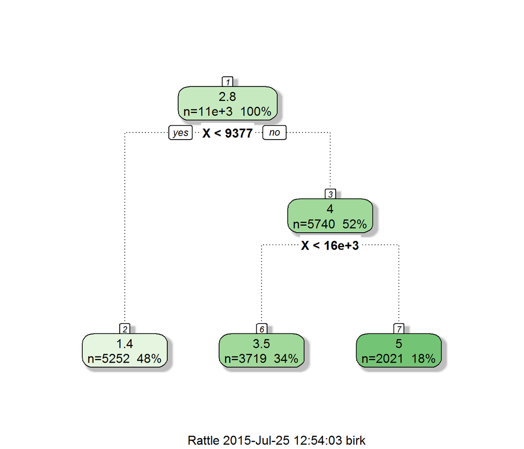

```r
predTestingRPART = round(predict(trainObjectRPARTcv, newdata = Testing))
confMatrixRPART = confusionMatrix(predTestingRPART, Testing$classe)
confMatrixRPART$overall['Accuracy']
```

```
##  Accuracy
## 0.6424474
```

```r
confMatrixRPART$overall['Kappa']
```

```
##     Kappa
## 0.5364177
```

[output not shown]

[output not shown]

```r
gmbGrid = expand.grid(cp=c(0.03, 0.035, 0.4, 0.45, 0.5, 0.55, 0.6, 0.65))
trainObjectRPARTTuned = train(classe ~ ., data = Training, method = "rpart", trControl = cvCtrl, tuneGrid = gmbGrid)
finalModelRPARTTuned = trainObjectRPARTTuned$finalModel
```

By plotting the model, we can see that the decision tree has more branches and an additional depth level compared to the previous model where c=0.45. The accuracy is up to 0.9994 and the kappa value is 0.9992.

[figure not shown]

**4. Generalized Boosted Regression Model(GBM) method with k-fold cross-validation**

Similar to th previous analysis, we are going to use k-fold cross validation where k=5 and the method we are going to apply for building the model is Generalized Boosted Regression Model(GBM).

```r
cvCtrl <- trainControl(method = "cv", number=5, allowParallel = TRUE)
trainObjectGBM = train(classe ~ ., data = Training, method = "gbm", trControl = cvCtrl)
finalModelGBM = trainObjectGBM$finalModel
```

By plotting the model we can see that the best results based on the RMSE are the once with tree depth equal to 3. This is aligned witht he results coming from the recursive partitioning where the best tree model built after tuning is a tree with 3 levels.

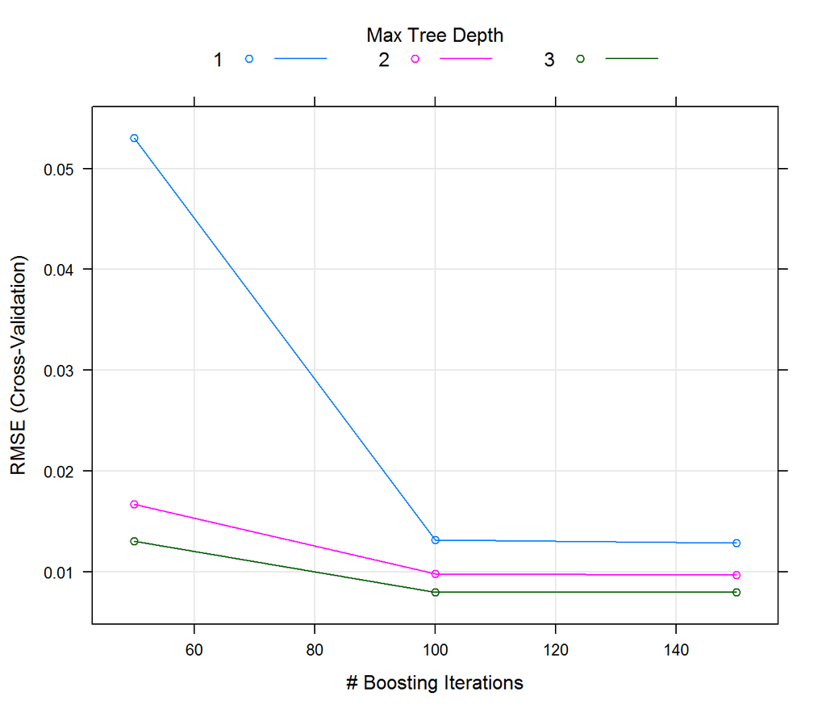

**5. Bagging method**

```r
cvCtrl <- trainControl(allowParallel = TRUE)
trainObjBAG = bag(Training[,c(0:53)], Training$classe, B=5,
                                        bagControl = bagControl(fit = ctreeBag$fit,
                                        predict = ctreeBag$pred,
                                        aggregate = ctreeBag$aggregate,
                                        allowParallel = TRUE))
```

```
## Accuracy
##        1
```

```
## Kappa
##     1
```

The model is using only the variable X from the data set in order to predict the values for classe. By plotting the model we can see the outcome classe is bagged by the X variable. There are five clearly described intervals of X which determine what the value of classe would be.

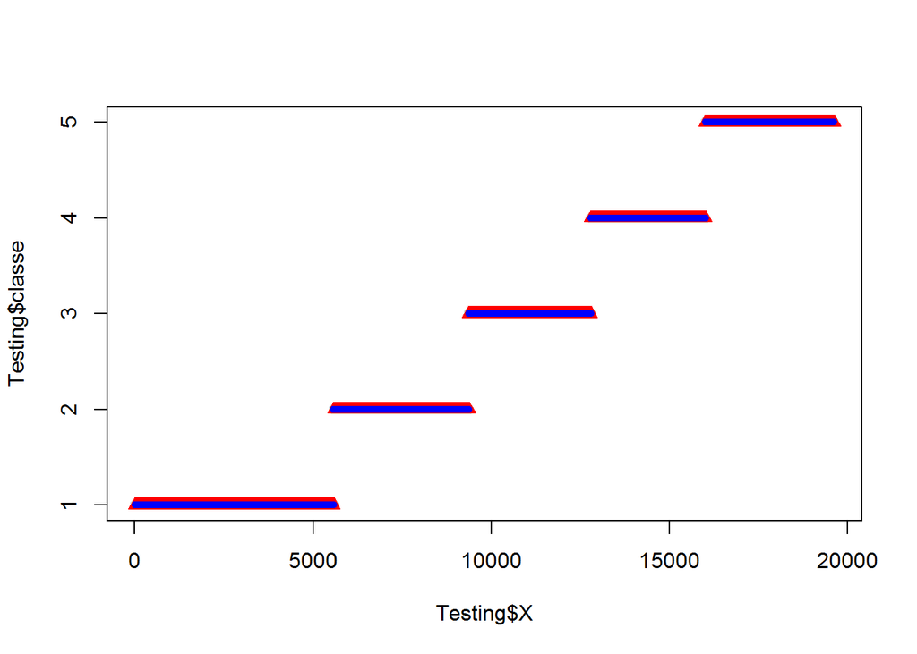

**6. Out of sample error**

In order to determine our out of sample error, we are going to look at the validation dataset that we created in the beginning of the analysis. The validation dataset was not used to build and/or improve any of our models and as such will be a good candidate to determine the out of sample error of our models.

First we need to pre process the validation dataset with the same methods we used for the training and testing datasets - creating dummy variables, finding the highly correlated and near zero variables. After the validation dataset is pre processed, we are going to apply our models and see what their out of sample errors would be.

First we are going to use the Linear regression model. The results are that the model predicts the data with Accuracy of 100% and kappa equal to 1. The case may be that the model is overfitting.

```r
predValidationleapForward <- round(predict(trainObjleapForward, newdata=Validation))
confMatrixLFvalidate = confusionMatrix(predValidationleapForward, Validation$classe)
confMatrixLFvalidate$overall['Accuracy']
```

```
## Accuracy
##        1
```

```r
confMatrixLFvalidate$overall['Kappa']
```

```
## Kappa
##     1
```

```
##  Accuracy
## 0.9994902
```

```
##     Kappa
## 0.9993551
```

```
##  Accuracy
## 0.9994902
```

```
##     Kappa
## 0.9993551
```

```
##  Accuracy
## 0.9994902
```

```
##     Kappa
## 0.9993551
```

The final model to evaluate is the BAG model. The bag model seems to be 100% accurate predictor of the model with kappa equal to 1 which means that the out of sample error should be 0.

```
## Accuracy
##        1
```

```
## Kappa
##     1
```

From all the models, it seems reasonable to choose as our best model either GBM or RPART. They have high enough accuracy and kappa values. We are still having the risk of over fitting with both of these models however it is reinforcing to know that both models are selecting as the best solution a tree with 3 levels and that the tree is based on the X variable.